# Welcome to Fabio’s Defense Website

The place to find all the information you for Dr. Fabio’s big day! ✨🚤👨🏻‍🎓✨

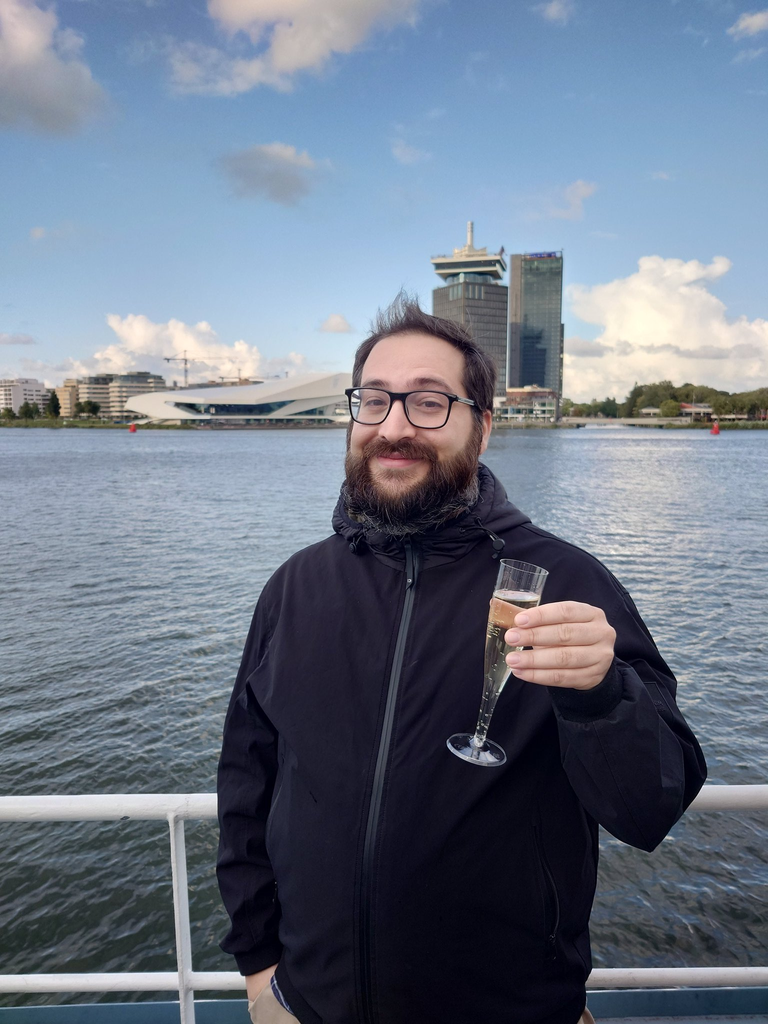

### First thing first, kindly RSVP by clicking the button below.

[RSVP](https://forms.gle/f4YLD5jomEYPTgKy7)

#### Join us and celebrate as our dear Fabio becomes …

```r
title <- "Dr."
name <- "Fabio Votta"
print(glue::glue("{title} {name}"))
```

```
## Dr. Fabio Votta
```

## > Event Information

**📅 Date:** Friday, April 19, 2024

*Click [here](https://calendar.google.com/calendar/u/4?cid=ZmFiaW8udm90dGEuZGVmZW5zZUBnbWFpbC5jb20) to download full day calendar invite and location information.*

### Defense Ceremony 🧑🏻‍🏫

**>📍 Location:** [Aula UvA, Singel 411, 1012 WN Amsterdam](https://www.google.com/maps/place//data=!4m2!3m1!1s0x47c609c193a4380f:0xccfdbd1232ff182d?sa=X&ved=2ahUKEwjXqt7Xy7WEAxUd_7sIHeA-A-4Q4kB6BAgPEAA)**

[interactive chart not shown]

> *Please arrive 30 minutes before starting time at **13:30** as entry is not allow once the ceremony starts.*

**📝 Program:**

| Time | Agenda |
| --- | --- |
| 13:30 | Arrival and entry |
| 14:00 | Start of Presentation (Layman’s Talk) |
| 14:10 | End of Presentation |

*5 MINUTES BREAK*

| Time | Agenda |
| --- | --- |
| 14:15 | Committee Entrance + Q&A session |
| 15:00 | Committee Decision |
| 15:30 | End of Defense Ceremony |

**🎥 Livestream Link:**

Click [here](https://www.uva.nl/en/research/phd/phd-defence-ceremony-agenda/phd-defence-ceremonies.html?t=fmg) to access the livestream.

**> 🚗🚇🚋 How To Get There**

Public Transport

🚇 Metro Station **Rokin** via *Metro 52 (Blue Line)*

🚋 Tram Station **Rokin** via *Tram 4*, *Tram 14*, and *Tram 24*

🚋 Tram Station **Koningsplein** via *Tram 2* and *Tram 12*

Car Parking Options:

*Note that finding a parking spot may be difficult*

🅿️ Stopera/Waterlooplein (Valkenburgerstraat 238)

🅿️ Q-Park de Bijenkorf (Beursstraat 15)

### Borrel 🍻

**🕐 Time:** 15:30 (3:30PM) -

*The borrel begins directly after the defense ceremony*

**📍 Location:** Aula UvA, Singel 411, 1012 WN Amsterdam

How to get there:

- Metro Station Rokin via Metro 52 (Blue Line)
- Tram Station Rokin via Tram 4, Tram 14, and Tram 24
- Tram Station Koningsplein via Tram 2 and Tram 12

Car Parking Options:

*Note that finding a parking spot may be difficult*

- Stopera/Waterlooplein (Valkenburgerstraat 238)
- Q-Park de Bijenkorf (Beursstraat 15)

[interactive chart not shown]

### Party 🎉

**📍 Location:** Amstelhaven, Op Professor Tulpplein / naast Amstelhotel, Mauritskade 1, 1091 EW Amsterdam

How to get there:

- Metro Station Wesperplein via Metro 51 (Orange Line), Metro 53 (Red Line), and Metro 54 (Yellow Line)
- Tram Station Wesperplein via Tram 1, Tram 7, and Tram 19

[interactive chart not shown]

## Event Media

**Instagram:** @fabiodefense

**Hashtag:** #DrFabio

### Please click the button below for information on Fabio’s gift (if you’re not Fabio)

🎁 Fabio’s Gift 🎁